# Risk Factor Analysis

## Outcome Variable

**Outcome Variable:** pers_wasted624

## Predictor Variables

**Intervention Variable:** ever_stunted06

**Adjustment Set:**

- sex
- arm
- enstunt
- month
- brthmon
- vagbrth
- single
- W_gagebrth
- W_birthwt
- W_birthlen
- W_mage
- W_mhtcm
- W_meducyrs
- W_feducyrs
- W_parity
- delta_month
- delta_brthmon
- delta_vagbrth
- delta_single
- delta_W_gagebrth
- delta_W_birthwt
- delta_W_birthlen
- delta_W_mage
- delta_W_mhtcm
- delta_W_meducyrs
- delta_W_feducyrs
- delta_W_parity

## Stratifying Variables

The analysis was stratified on these variable(s):

- studyid
- country

## Data Summary

| studyid | country | ever_stunted06 | pers_wasted624 | n_cell | n |
| --- | --- | --- | --- | --- | --- |
| ki0047075b-MAL-ED | BANGLADESH | 0 | 0 | 145 | 240 |
| ki0047075b-MAL-ED | BANGLADESH | 0 | 1 | 10 | 240 |
| ki0047075b-MAL-ED | BANGLADESH | 1 | 0 | 77 | 240 |
| ki0047075b-MAL-ED | BANGLADESH | 1 | 1 | 8 | 240 |
| ki0047075b-MAL-ED | BRAZIL | 0 | 0 | 165 | 207 |
| ki0047075b-MAL-ED | BRAZIL | 0 | 1 | 2 | 207 |
| ki0047075b-MAL-ED | BRAZIL | 1 | 0 | 40 | 207 |
| ki0047075b-MAL-ED | BRAZIL | 1 | 1 | 0 | 207 |
| ki0047075b-MAL-ED | INDIA | 0 | 0 | 136 | 235 |
| ki0047075b-MAL-ED | INDIA | 0 | 1 | 14 | 235 |
| ki0047075b-MAL-ED | INDIA | 1 | 0 | 71 | 235 |
| ki0047075b-MAL-ED | INDIA | 1 | 1 | 14 | 235 |
| ki0047075b-MAL-ED | NEPAL | 0 | 0 | 192 | 235 |
| ki0047075b-MAL-ED | NEPAL | 0 | 1 | 1 | 235 |
| ki0047075b-MAL-ED | NEPAL | 1 | 0 | 41 | 235 |
| ki0047075b-MAL-ED | NEPAL | 1 | 1 | 1 | 235 |
| ki0047075b-MAL-ED | PERU | 0 | 0 | 147 | 270 |
| ki0047075b-MAL-ED | PERU | 0 | 1 | 0 | 270 |
| ki0047075b-MAL-ED | PERU | 1 | 0 | 121 | 270 |
| ki0047075b-MAL-ED | PERU | 1 | 1 | 2 | 270 |
| ki0047075b-MAL-ED | SOUTH AFRICA | 0 | 0 | 153 | 259 |
| ki0047075b-MAL-ED | SOUTH AFRICA | 0 | 1 | 2 | 259 |
| ki0047075b-MAL-ED | SOUTH AFRICA | 1 | 0 | 104 | 259 |
| ki0047075b-MAL-ED | SOUTH AFRICA | 1 | 1 | 0 | 259 |
| ki0047075b-MAL-ED | TANZANIA, UNITED REPUBLIC OF | 0 | 0 | 141 | 245 |
| ki0047075b-MAL-ED | TANZANIA, UNITED REPUBLIC OF | 0 | 1 | 0 | 245 |
| ki0047075b-MAL-ED | TANZANIA, UNITED REPUBLIC OF | 1 | 0 | 104 | 245 |
| ki0047075b-MAL-ED | TANZANIA, UNITED REPUBLIC OF | 1 | 1 | 0 | 245 |
| ki1000108-CMC-V-BCS-2002 | INDIA | 0 | 0 | 167 | 370 |
| ki1000108-CMC-V-BCS-2002 | INDIA | 0 | 1 | 11 | 370 |

[output cut: 102 more lines]

The following strata were considered:

- studyid: ki0047075b-MAL-ED, country: BANGLADESH
- studyid: ki0047075b-MAL-ED, country: BRAZIL
- studyid: ki0047075b-MAL-ED, country: INDIA
- studyid: ki0047075b-MAL-ED, country: NEPAL
- studyid: ki0047075b-MAL-ED, country: PERU
- studyid: ki0047075b-MAL-ED, country: SOUTH AFRICA
- studyid: ki0047075b-MAL-ED, country: TANZANIA, UNITED REPUBLIC OF
- studyid: ki1000108-CMC-V-BCS-2002, country: INDIA
- studyid: ki1000108-IRC, country: INDIA
- studyid: ki1000109-EE, country: PAKISTAN
- studyid: ki1000109-ResPak, country: PAKISTAN
- studyid: ki1000304b-SAS-CompFeed, country: INDIA
- studyid: ki1000304b-SAS-FoodSuppl, country: INDIA
- studyid: ki1017093-NIH-Birth, country: BANGLADESH
- studyid: ki1017093b-PROVIDE, country: BANGLADESH
- studyid: ki1017093c-NIH-Crypto, country: BANGLADESH
- studyid: ki1066203-TanzaniaChild2, country: TANZANIA, UNITED REPUBLIC OF
- studyid: ki1101329-Keneba, country: GAMBIA
- studyid: ki1112895-Guatemala BSC, country: GUATEMALA
- studyid: ki1113344-GMS-Nepal, country: NEPAL
- studyid: ki1114097-CMIN, country: BANGLADESH
- studyid: ki1114097-CMIN, country: BRAZIL
- studyid: ki1114097-CMIN, country: GUINEA-BISSAU
- studyid: ki1114097-CMIN, country: PERU
- studyid: ki1114097-CONTENT, country: PERU
- studyid: ki1119695-PROBIT, country: BELARUS
- studyid: ki1126311-ZVITAMBO, country: ZIMBABWE
- studyid: ki1135781-COHORTS, country: GUATEMALA
- studyid: ki1135781-COHORTS, country: INDIA
- studyid: ki1135781-COHORTS, country: PHILIPPINES
- studyid: ki1148112-LCNI-5, country: MALAWI
- studyid: kiGH5241-JiVitA-3, country: BANGLADESH
- studyid: kiGH5241-JiVitA-4, country: BANGLADESH

### Dropped Strata

Some strata were dropped due to rare outcomes:

- studyid: ki0047075b-MAL-ED, country: BRAZIL
- studyid: ki0047075b-MAL-ED, country: NEPAL
- studyid: ki0047075b-MAL-ED, country: PERU
- studyid: ki0047075b-MAL-ED, country: SOUTH AFRICA
- studyid: ki0047075b-MAL-ED, country: TANZANIA, UNITED REPUBLIC OF
- studyid: ki1112895-Guatemala BSC, country: GUATEMALA
- studyid: ki1114097-CMIN, country: BANGLADESH
- studyid: ki1114097-CMIN, country: BRAZIL
- studyid: ki1114097-CMIN, country: PERU
- studyid: ki1114097-CONTENT, country: PERU
- studyid: ki1148112-LCNI-5, country: MALAWI

## Methods Detail

We’re interested in the causal parameters $E[Y_a]$ for all values of $a \in \mathcal{A}$. These parameters represent the mean outcome if, possibly contrary to fact, we intervened to set all units to have $A=a$. Under the randomization and positivity assumptions, these are identified by the statistical parameters $\psi_a=E_W[E_{Y|A,W}(Y|A=a,W)]$. In addition, we’re interested in the mean of $Y$, $E[Y]$ under no intervention (the observed mean). We will estimate these parameters by using SuperLearner to fit the relevant likelihood factors – $E_{Y|A,W}(Y|A=a,W)$ and $p(A=a|W)$, and then updating our likelihood fit using a joint TMLE.

For unadjusted analyses ($W=\{\}$), initial likelihoods were estimated using Lrnr_glm to estimate the simple $E(Y|A)$ and Lrnr_mean to estimate $p(A)$. For adjusted analyses, a small library containing Lrnr_glmnet, Lrnr_xgboost, and Lrnr_mean was used.

Having estimated these parameters, we will then use the delta method to estimate relative risks and attributable risks relative to a prespecified baseline level of $A$.

# Results Detail

## Results Plots

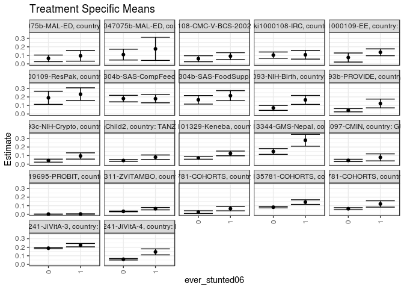

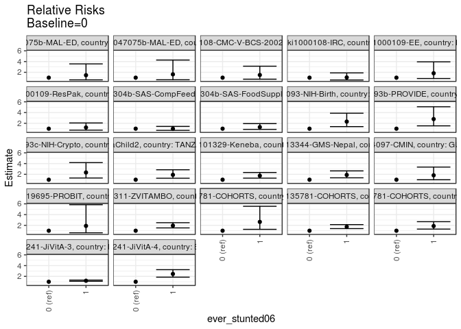

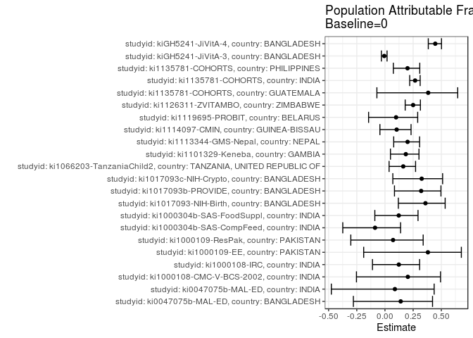

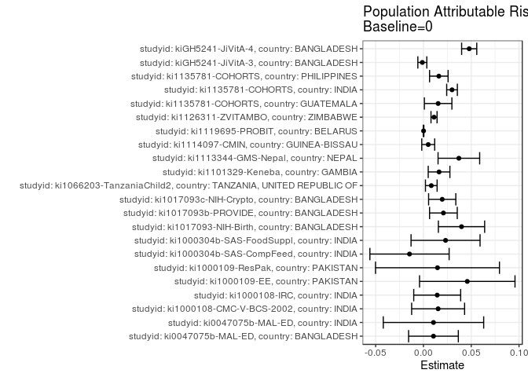

## Results Table

### Parameter: TSM

| studyid | country | intervention_level | baseline_level | estimate | ci_lower | ci_upper |
| --- | --- | --- | --- | --- | --- | --- |
| ki0047075b-MAL-ED | BANGLADESH | 0 | NA | 0.0645161 | 0.0257599 | 0.1032723 |
| ki0047075b-MAL-ED | BANGLADESH | 1 | NA | 0.0941176 | 0.0319139 | 0.1563214 |
| ki0047075b-MAL-ED | INDIA | 0 | NA | 0.1086475 | 0.0449697 | 0.1723254 |
| ki0047075b-MAL-ED | INDIA | 1 | NA | 0.1760505 | 0.0402554 | 0.3118456 |
| ki1000108-CMC-V-BCS-2002 | INDIA | 0 | NA | 0.0603114 | 0.0251541 | 0.0954687 |
| ki1000108-CMC-V-BCS-2002 | INDIA | 1 | NA | 0.0904289 | 0.0497565 | 0.1311013 |
| ki1000108-IRC | INDIA | 0 | NA | 0.1026778 | 0.0661771 | 0.1391785 |
| ki1000108-IRC | INDIA | 1 | NA | 0.1067221 | 0.0558272 | 0.1576170 |
| ki1000109-EE | PAKISTAN | 0 | NA | 0.0744681 | 0.0213251 | 0.1276111 |
| ki1000109-EE | PAKISTAN | 1 | NA | 0.1357143 | 0.0955452 | 0.1758834 |
| ki1000109-ResPak | PAKISTAN | 0 | NA | 0.1896445 | 0.1128650 | 0.2664239 |
| ki1000109-ResPak | PAKISTAN | 1 | NA | 0.2322980 | 0.1578578 | 0.3067382 |
| ki1000304b-SAS-CompFeed | INDIA | 0 | NA | 0.1802869 | 0.1421716 | 0.2184023 |
| ki1000304b-SAS-CompFeed | INDIA | 1 | NA | 0.1789872 | 0.1310923 | 0.2268820 |
| ki1000304b-SAS-FoodSuppl | INDIA | 0 | NA | 0.1659204 | 0.1159334 | 0.2159075 |
| ki1000304b-SAS-FoodSuppl | INDIA | 1 | NA | 0.2145849 | 0.1554844 | 0.2736854 |
| ki1017093-NIH-Birth | BANGLADESH | 0 | NA | 0.0710748 | 0.0422276 | 0.0999219 |
| ki1017093-NIH-Birth | BANGLADESH | 1 | NA | 0.1648387 | 0.1125911 | 0.2170864 |
| ki1017093b-PROVIDE | BANGLADESH | 0 | NA | 0.0441524 | 0.0252319 | 0.0630729 |
| ki1017093b-PROVIDE | BANGLADESH | 1 | NA | 0.1231108 | 0.0714902 | 0.1747314 |
| ki1017093c-NIH-Crypto | BANGLADESH | 0 | NA | 0.0406338 | 0.0231057 | 0.0581619 |
| ki1017093c-NIH-Crypto | BANGLADESH | 1 | NA | 0.0952915 | 0.0586266 | 0.1319565 |
| ki1066203-TanzaniaChild2 | TANZANIA, UNITED REPUBLIC OF | 0 | NA | 0.0423419 | 0.0323480 | 0.0523357 |
| ki1066203-TanzaniaChild2 | TANZANIA, UNITED REPUBLIC OF | 1 | NA | 0.0807098 | 0.0544804 | 0.1069392 |
| ki1101329-Keneba | GAMBIA | 0 | NA | 0.0719645 | 0.0574333 | 0.0864957 |
| ki1101329-Keneba | GAMBIA | 1 | NA | 0.1251397 | 0.0975572 | 0.1527222 |
| ki1113344-GMS-Nepal | NEPAL | 0 | NA | 0.1476887 | 0.1141505 | 0.1812269 |
| ki1113344-GMS-Nepal | NEPAL | 1 | NA | 0.2789366 | 0.2099487 | 0.3479245 |
| ki1114097-CMIN | GUINEA-BISSAU | 0 | NA | 0.0431754 | 0.0296055 | 0.0567453 |
| ki1114097-CMIN | GUINEA-BISSAU | 1 | NA | 0.0785662 | 0.0374227 | 0.1197097 |
| ki1119695-PROBIT | BELARUS | 0 | NA | 0.0013038 | 0.0002440 | 0.0023635 |
| ki1119695-PROBIT | BELARUS | 1 | NA | 0.0024728 | 0.0001388 | 0.0048068 |
| ki1126311-ZVITAMBO | ZIMBABWE | 0 | NA | 0.0332214 | 0.0291029 | 0.0373398 |
| ki1126311-ZVITAMBO | ZIMBABWE | 1 | NA | 0.0646901 | 0.0509184 | 0.0784618 |
| ki1135781-COHORTS | GUATEMALA | 0 | NA | 0.0247055 | 0.0091356 | 0.0402753 |
| ki1135781-COHORTS | GUATEMALA | 1 | NA | 0.0652305 | 0.0394455 | 0.0910156 |
| ki1135781-COHORTS | INDIA | 0 | NA | 0.0819525 | 0.0744969 | 0.0894080 |
| ki1135781-COHORTS | INDIA | 1 | NA | 0.1416521 | 0.1143229 | 0.1689812 |
| ki1135781-COHORTS | PHILIPPINES | 0 | NA | 0.0643522 | 0.0522709 | 0.0764336 |
| ki1135781-COHORTS | PHILIPPINES | 1 | NA | 0.1202714 | 0.0831532 | 0.1573897 |
| kiGH5241-JiVitA-3 | BANGLADESH | 0 | NA | 0.1889448 | 0.1831722 | 0.1947173 |
| kiGH5241-JiVitA-3 | BANGLADESH | 1 | NA | 0.2244966 | 0.2047280 | 0.2442651 |
| kiGH5241-JiVitA-4 | BANGLADESH | 0 | NA | 0.0594101 | 0.0509310 | 0.0678891 |
| kiGH5241-JiVitA-4 | BANGLADESH | 1 | NA | 0.1456881 | 0.1105787 | 0.1807975 |

### Parameter: E(Y)

| studyid | country | intervention_level | baseline_level | estimate | ci_lower | ci_upper |
| --- | --- | --- | --- | --- | --- | --- |
| ki0047075b-MAL-ED | BANGLADESH | NA | NA | 0.0750000 | 0.0416074 | 0.1083926 |
| ki0047075b-MAL-ED | INDIA | NA | NA | 0.1191489 | 0.0776405 | 0.1606574 |
| ki1000108-CMC-V-BCS-2002 | INDIA | NA | NA | 0.0756757 | 0.0486905 | 0.1026609 |
| ki1000108-IRC | INDIA | NA | NA | 0.1170732 | 0.0859146 | 0.1482317 |
| ki1000109-EE | PAKISTAN | NA | NA | 0.1203209 | 0.0873047 | 0.1533370 |
| ki1000109-ResPak | PAKISTAN | NA | NA | 0.2043478 | 0.1521230 | 0.2565727 |
| ki1000304b-SAS-CompFeed | INDIA | NA | NA | 0.1657061 | 0.1471754 | 0.1842367 |
| ki1000304b-SAS-FoodSuppl | INDIA | NA | NA | 0.1890547 | 0.1507312 | 0.2273783 |
| ki1017093-NIH-Birth | BANGLADESH | NA | NA | 0.1109057 | 0.0844206 | 0.1373909 |
| ki1017093b-PROVIDE | BANGLADESH | NA | NA | 0.0650407 | 0.0455353 | 0.0845460 |
| ki1017093c-NIH-Crypto | BANGLADESH | NA | NA | 0.0602740 | 0.0429977 | 0.0775502 |
| ki1066203-TanzaniaChild2 | TANZANIA, UNITED REPUBLIC OF | NA | NA | 0.0505451 | 0.0409848 | 0.0601054 |
| ki1101329-Keneba | GAMBIA | NA | NA | 0.0882993 | 0.0766987 | 0.0998998 |
| ki1113344-GMS-Nepal | NEPAL | NA | NA | 0.1847458 | 0.1534039 | 0.2160876 |
| ki1114097-CMIN | GUINEA-BISSAU | NA | NA | 0.0481809 | 0.0350130 | 0.0613488 |
| ki1119695-PROBIT | BELARUS | NA | NA | 0.0014462 | 0.0004207 | 0.0024717 |
| ki1126311-ZVITAMBO | ZIMBABWE | NA | NA | 0.0442925 | 0.0403901 | 0.0481949 |
| ki1135781-COHORTS | GUATEMALA | NA | NA | 0.0400782 | 0.0280529 | 0.0521035 |
| ki1135781-COHORTS | INDIA | NA | NA | 0.1118526 | 0.1044114 | 0.1192938 |
| ki1135781-COHORTS | PHILIPPINES | NA | NA | 0.0804557 | 0.0703953 | 0.0905161 |
| kiGH5241-JiVitA-3 | BANGLADESH | NA | NA | 0.1877787 | 0.1812440 | 0.1943134 |
| kiGH5241-JiVitA-4 | BANGLADESH | NA | NA | 0.1072855 | 0.0967458 | 0.1178252 |

### Parameter: RR

| studyid | country | intervention_level | baseline_level | estimate | ci_lower | ci_upper |
| --- | --- | --- | --- | --- | --- | --- |
| ki0047075b-MAL-ED | BANGLADESH | 0 | 0 | 1.0000000 | 1.0000000 | 1.000000 |
| ki0047075b-MAL-ED | BANGLADESH | 1 | 0 | 1.4588235 | 0.5972043 | 3.563548 |
| ki0047075b-MAL-ED | INDIA | 0 | 0 | 1.0000000 | 1.0000000 | 1.000000 |
| ki0047075b-MAL-ED | INDIA | 1 | 0 | 1.6203818 | 0.6135982 | 4.279082 |
| ki1000108-CMC-V-BCS-2002 | INDIA | 0 | 0 | 1.0000000 | 1.0000000 | 1.000000 |
| ki1000108-CMC-V-BCS-2002 | INDIA | 1 | 0 | 1.4993672 | 0.7171862 | 3.134614 |
| ki1000108-IRC | INDIA | 0 | 0 | 1.0000000 | 1.0000000 | 1.000000 |
| ki1000108-IRC | INDIA | 1 | 0 | 1.0393882 | 0.5720767 | 1.888432 |
| ki1000109-EE | PAKISTAN | 0 | 0 | 1.0000000 | 1.0000000 | 1.000000 |
| ki1000109-EE | PAKISTAN | 1 | 0 | 1.8224490 | 0.8416430 | 3.946234 |
| ki1000109-ResPak | PAKISTAN | 0 | 0 | 1.0000000 | 1.0000000 | 1.000000 |
| ki1000109-ResPak | PAKISTAN | 1 | 0 | 1.2249131 | 0.7269422 | 2.064005 |
| ki1000304b-SAS-CompFeed | INDIA | 0 | 0 | 1.0000000 | 1.0000000 | 1.000000 |
| ki1000304b-SAS-CompFeed | INDIA | 1 | 0 | 0.9927905 | 0.6910781 | 1.426225 |
| ki1000304b-SAS-FoodSuppl | INDIA | 0 | 0 | 1.0000000 | 1.0000000 | 1.000000 |
| ki1000304b-SAS-FoodSuppl | INDIA | 1 | 0 | 1.2932999 | 0.8596736 | 1.945651 |
| ki1017093-NIH-Birth | BANGLADESH | 0 | 0 | 1.0000000 | 1.0000000 | 1.000000 |
| ki1017093-NIH-Birth | BANGLADESH | 1 | 0 | 2.3192303 | 1.3860547 | 3.880676 |
| ki1017093b-PROVIDE | BANGLADESH | 0 | 0 | 1.0000000 | 1.0000000 | 1.000000 |
| ki1017093b-PROVIDE | BANGLADESH | 1 | 0 | 2.7883154 | 1.5307095 | 5.079150 |
| ki1017093c-NIH-Crypto | BANGLADESH | 0 | 0 | 1.0000000 | 1.0000000 | 1.000000 |
| ki1017093c-NIH-Crypto | BANGLADESH | 1 | 0 | 2.3451263 | 1.3159385 | 4.179236 |
| ki1066203-TanzaniaChild2 | TANZANIA, UNITED REPUBLIC OF | 0 | 0 | 1.0000000 | 1.0000000 | 1.000000 |
| ki1066203-TanzaniaChild2 | TANZANIA, UNITED REPUBLIC OF | 1 | 0 | 1.9061475 | 1.2752732 | 2.849114 |
| ki1101329-Keneba | GAMBIA | 0 | 0 | 1.0000000 | 1.0000000 | 1.000000 |
| ki1101329-Keneba | GAMBIA | 1 | 0 | 1.7389089 | 1.2913692 | 2.341549 |
| ki1113344-GMS-Nepal | NEPAL | 0 | 0 | 1.0000000 | 1.0000000 | 1.000000 |
| ki1113344-GMS-Nepal | NEPAL | 1 | 0 | 1.8886789 | 1.3515066 | 2.639357 |
| ki1114097-CMIN | GUINEA-BISSAU | 0 | 0 | 1.0000000 | 1.0000000 | 1.000000 |
| ki1114097-CMIN | GUINEA-BISSAU | 1 | 0 | 1.8196990 | 0.9889758 | 3.348216 |
| ki1119695-PROBIT | BELARUS | 0 | 0 | 1.0000000 | 1.0000000 | 1.000000 |
| ki1119695-PROBIT | BELARUS | 1 | 0 | 1.8966370 | 0.6161343 | 5.838390 |
| ki1126311-ZVITAMBO | ZIMBABWE | 0 | 0 | 1.0000000 | 1.0000000 | 1.000000 |
| ki1126311-ZVITAMBO | ZIMBABWE | 1 | 0 | 1.9472445 | 1.5223728 | 2.490692 |
| ki1135781-COHORTS | GUATEMALA | 0 | 0 | 1.0000000 | 1.0000000 | 1.000000 |
| ki1135781-COHORTS | GUATEMALA | 1 | 0 | 2.6403275 | 1.2564095 | 5.548612 |
| ki1135781-COHORTS | INDIA | 0 | 0 | 1.0000000 | 1.0000000 | 1.000000 |
| ki1135781-COHORTS | INDIA | 1 | 0 | 1.7284660 | 1.3977723 | 2.137397 |
| ki1135781-COHORTS | PHILIPPINES | 0 | 0 | 1.0000000 | 1.0000000 | 1.000000 |
| ki1135781-COHORTS | PHILIPPINES | 1 | 0 | 1.8689544 | 1.3034338 | 2.679838 |
| kiGH5241-JiVitA-3 | BANGLADESH | 0 | 0 | 1.0000000 | 1.0000000 | 1.000000 |
| kiGH5241-JiVitA-3 | BANGLADESH | 1 | 0 | 1.1881598 | 1.0842925 | 1.301977 |
| kiGH5241-JiVitA-4 | BANGLADESH | 0 | 0 | 1.0000000 | 1.0000000 | 1.000000 |
| kiGH5241-JiVitA-4 | BANGLADESH | 1 | 0 | 2.4522459 | 1.8539208 | 3.243671 |

### Parameter: PAR

| studyid | country | intervention_level | baseline_level | estimate | ci_lower | ci_upper |
| --- | --- | --- | --- | --- | --- | --- |
| ki0047075b-MAL-ED | BANGLADESH | 0 | NA | 0.0104839 | -0.0155348 | 0.0365026 |
| ki0047075b-MAL-ED | INDIA | 0 | NA | 0.0105014 | -0.0420257 | 0.0630285 |
| ki1000108-CMC-V-BCS-2002 | INDIA | 0 | NA | 0.0153643 | -0.0123353 | 0.0430638 |
| ki1000108-IRC | INDIA | 0 | NA | 0.0143954 | -0.0101584 | 0.0389492 |
| ki1000109-EE | PAKISTAN | 0 | NA | 0.0458528 | -0.0040933 | 0.0957988 |
| ki1000109-ResPak | PAKISTAN | 0 | NA | 0.0147033 | -0.0501303 | 0.0795370 |
| ki1000304b-SAS-CompFeed | INDIA | 0 | NA | -0.0145809 | -0.0560324 | 0.0268706 |
| ki1000304b-SAS-FoodSuppl | INDIA | 0 | NA | 0.0231343 | -0.0129657 | 0.0592342 |
| ki1017093-NIH-Birth | BANGLADESH | 0 | NA | 0.0398310 | 0.0156190 | 0.0640429 |
| ki1017093b-PROVIDE | BANGLADESH | 0 | NA | 0.0208882 | 0.0063972 | 0.0353792 |
| ki1017093c-NIH-Crypto | BANGLADESH | 0 | NA | 0.0196401 | 0.0053991 | 0.0338811 |
| ki1066203-TanzaniaChild2 | TANZANIA, UNITED REPUBLIC OF | 0 | NA | 0.0082032 | 0.0020989 | 0.0143076 |
| ki1101329-Keneba | GAMBIA | 0 | NA | 0.0163348 | 0.0049911 | 0.0276784 |
| ki1113344-GMS-Nepal | NEPAL | 0 | NA | 0.0370570 | 0.0152849 | 0.0588292 |
| ki1114097-CMIN | GUINEA-BISSAU | 0 | NA | 0.0050055 | -0.0017548 | 0.0117659 |
| ki1119695-PROBIT | BELARUS | 0 | NA | 0.0001424 | -0.0001556 | 0.0004405 |
| ki1126311-ZVITAMBO | ZIMBABWE | 0 | NA | 0.0110712 | 0.0079024 | 0.0142400 |
| ki1135781-COHORTS | GUATEMALA | 0 | NA | 0.0153727 | 0.0009720 | 0.0297735 |
| ki1135781-COHORTS | INDIA | 0 | NA | 0.0299001 | 0.0243100 | 0.0354902 |
| ki1135781-COHORTS | PHILIPPINES | 0 | NA | 0.0161034 | 0.0064073 | 0.0257996 |
| kiGH5241-JiVitA-3 | BANGLADESH | 0 | NA | -0.0011660 | -0.0058596 | 0.0035276 |
| kiGH5241-JiVitA-4 | BANGLADESH | 0 | NA | 0.0478755 | 0.0399622 | 0.0557887 |

### Parameter: PAF

| studyid | country | intervention_level | baseline_level | estimate | ci_lower | ci_upper |
| --- | --- | --- | --- | --- | --- | --- |
| ki0047075b-MAL-ED | BANGLADESH | 0 | NA | 0.1397849 | -0.2802981 | 0.4220331 |
| ki0047075b-MAL-ED | INDIA | 0 | NA | 0.0881368 | -0.4756042 | 0.4365057 |
| ki1000108-CMC-V-BCS-2002 | INDIA | 0 | NA | 0.2030281 | -0.2529594 | 0.4930688 |
| ki1000108-IRC | INDIA | 0 | NA | 0.1229606 | -0.1106390 | 0.3074274 |
| ki1000109-EE | PAKISTAN | 0 | NA | 0.3810875 | -0.1888599 | 0.6777983 |
| ki1000109-ResPak | PAKISTAN | 0 | NA | 0.0719525 | -0.3030814 | 0.3390496 |
| ki1000304b-SAS-CompFeed | INDIA | 0 | NA | -0.0879925 | -0.3743571 | 0.1387044 |
| ki1000304b-SAS-FoodSuppl | INDIA | 0 | NA | 0.1223682 | -0.0899031 | 0.2932972 |
| ki1017093-NIH-Birth | BANGLADESH | 0 | NA | 0.3591426 | 0.1186025 | 0.5340374 |
| ki1017093b-PROVIDE | BANGLADESH | 0 | NA | 0.3211568 | 0.0843437 | 0.4967237 |
| ki1017093c-NIH-Crypto | BANGLADESH | 0 | NA | 0.3258475 | 0.0696812 | 0.5114776 |
| ki1066203-TanzaniaChild2 | TANZANIA, UNITED REPUBLIC OF | 0 | NA | 0.1622953 | 0.0366812 | 0.2715298 |
| ki1101329-Keneba | GAMBIA | 0 | NA | 0.1849933 | 0.0488115 | 0.3016779 |
| ki1113344-GMS-Nepal | NEPAL | 0 | NA | 0.2005839 | 0.0775394 | 0.3072159 |
| ki1114097-CMIN | GUINEA-BISSAU | 0 | NA | 0.1038903 | -0.0448179 | 0.2314330 |
| ki1119695-PROBIT | BELARUS | 0 | NA | 0.0984898 | -0.1451996 | 0.2903240 |
| ki1126311-ZVITAMBO | ZIMBABWE | 0 | NA | 0.2499560 | 0.1794181 | 0.3144304 |
| ki1135781-COHORTS | GUATEMALA | 0 | NA | 0.3835686 | -0.0716032 | 0.6454027 |
| ki1135781-COHORTS | INDIA | 0 | NA | 0.2673172 | 0.2194403 | 0.3122575 |
| ki1135781-COHORTS | PHILIPPINES | 0 | NA | 0.2001529 | 0.0744701 | 0.3087685 |
| kiGH5241-JiVitA-3 | BANGLADESH | 0 | NA | -0.0062095 | -0.0316322 | 0.0185868 |
| kiGH5241-JiVitA-4 | BANGLADESH | 0 | NA | 0.4462434 | 0.3846099 | 0.5017041 |